# IPCC 2021

DS-SL

2022-11-15

# About

- [IPCC Sixth Assessment Report Working Group 1: The Physical Science Basis}(https://www.ipcc.ch/report/ar6/wg1/)
  - Data: [The Physical Science Basis. Working Group I Contribution to the IPCC Sixth Assessment Report](https://catalogue.ceda.ac.uk/uuid/3234e9111d4f4354af00c3aaecd879b7)
  - Code: [IPCC-WG1 Official GitHub repository for IPCC-WG1](https://github.com/IPCC-WG1)
    - There are 106 repositories
    - List of Popular Repositories
      - Atlas: 168 forks
      - Chapter 9: 11 forks
      - colormaps: 9 forks
      - Chapter 7: 6 forks
      - Chapter 12: 5 forks
      - tsu-colormaps: 1 fork
- Our World in Data: Data Explorer: IPCC Scenarios
  - Data and figures are available

## IPCC Repositories

### Atlas

- [Repository](https://github.com/IPCC-WG1/Atlas): Repository supporting the implementation of FAIR principles in the IPCC-WGI Atlas
  - [IPCC WGI Interactive Atlas](https://interactive-atlas.ipcc.ch)
    - Regional Information
    - Regional Synthesis
    - Documentation

### Chapter 9

- [Repository](https://github.com/IPCC-WG1/Chapter-9#repository-with-the-code-and-data-for-all-figures-from-chapter-9-of-the-sixth-assesment-report-from-the-intergovernmental-panel-on-climate-change-ipcc-ar6): Repository with the code and data for all figures from Chapter 9 of the Sixth Assesment Report from the Intergovernmental Panel on Climate Change (IPCC AR6).

# Our World Data

## Setup

```r
library(tidyverse)
```

## IPCC Senarios

- Data Published by: Riahi et al. (2017). The Shared Socioeconomic Pathways and their energy, land use, and greenhouse gas emissions implications: An overview, Global Environmental Change
  - Source: https://tntcat.iiasa.ac.at/SspDb/dsd
  - Riahi, K., Van Vuuren, D. P., Kriegler, E., Edmonds, J., O’neill, B. C., Fujimori, S., … & Tavoni, M. (2017). The shared socioeconomic pathways and their energy, land use, and greenhouse gas emissions implications: an overview. Global environmental change, 42, 153-168
    - [Original Paper](https://www.sciencedirect.com/science/article/pii/S0959378016300681)
- What is the Shared Socioeconomic Pathways (SSPs)
- Five Summaries:
  - SSP1 provides the most positive scenario for both human development and environmental action. We continue to see improvements in education and health across the world; large reductions in poverty; and a shrinking in global inequalities. This is a scenario in which the researchers at the same time envision that the world is moving into a much more sustainable direction.
  - SSP5 is similarly optimistic in terms of human development, but achieves this through a large growth in fossil fuels. This is therefore leading to continued large negative effects on the environment.
  - SSP3 and SSP4 are pessimistic about development: they envision a divided future with high levels of nationalism and large persistent global inequalities as a result. SSP2 sits in the middle of these scenarios: development is not as slow or divided as in SSP3 and SSP4, but progress is slow and unequal.

```r
df_owd1 <- read_csv("data/ipcc-scenarios.csv")
df_owd1
```

| Scenario | Year | Crop demand | Energy crop demand | Livestock demand | Energy crop production | Non-energy crop production | Livestock production | Carbon price | Methane concentration | CO2 concentration | Nitrous oxide concentration | Economic consumption | Economic consumption ($) | Electricity capacity | Biomass capacity | Coal capacity | Concentrated solar capacity | Gas capacity | Geothermal capacity | Hydropower capacity | Nuclear capacity | Offshore wind capacity | Oil capacity | Onshore wind capacity | Other electricity capacity | Solar capacity | Solar PV capacity | Wind capacity | Black carbon emissions | … |
| --- | --- | --- | --- | --- | --- | --- | --- | --- | --- | --- | --- | --- | --- | --- | --- | --- | --- | --- | --- | --- | --- | --- | --- | --- | --- | --- | --- | --- | --- | --- |
| SSP1 - 1.9 | 2005 | 3389946625 | NA | 238986476 | 31469669 | 3417340000 | 238986500 | 0.0000000 | 1753.160 | 379.8500 | 319.8550 | 34531.70 | 3.453170e+13 | 3797.849 | 66.799260 | 967.114172 | 4.084514e-01 | 1011.0060 | NA | 871.2293 | 403.097000 | 0.6842001 | 405.4770781 | 58.03196 | 9.507541 | 4.902305 | 4.493854 | 58.71616 | 10166850 | … |
| SSP1 - 1.9 | 2010 | 3780159000 | NA | 262440747 | 56039029 | 3813367000 | 262440781 | 0.0000000 | 1812.864 | 390.5053 | 323.6896 | 40443.00 | 4.044300e+13 | 4523.660 | 80.587719 | 1139.278000 | 1.256000e+00 | 1170.6742 | NA | 1028.1110 | 422.762688 | 3.1927000 | 434.5955625 | 193.14200 | 11.241270 | 40.074352 | 38.818352 | 196.33470 | 10420980 | … |
| SSP1 - 1.9 | 2020 | 4330961000 | NA | 289096842 | 91136860 | 4354620000 | 289096875 | 0.0000000 | 1812.021 | 412.1420 | 330.4511 | 60738.12 | 6.073812e+13 | 5775.863 | 185.241861 | 1089.114376 | 8.269087e+00 | 1616.2540 | NA | 1314.2830 | 452.064500 | 19.4380703 | 325.0383452 | 470.42109 | 16.975949 | 287.031587 | 278.762500 | 489.85916 | 7281273 | … |
| SSP1 - 1.9 | 2030 | 4764790750 | NA | 309853936 | 445930840 | 4944219000 | 309853906 | 303.6736287 | 1631.172 | 424.6815 | 335.0645 | 94211.73 | 9.421173e+13 | 5656.165 | 223.648557 | 871.768742 | 1.859721e+01 | 1469.2449 | NA | 1430.7620 | 452.457313 | 51.1482500 | 248.7838722 | 476.08431 | 27.493359 | 404.774211 | 386.177000 | 527.23256 | 3990174 | … |
| SSP1 - 1.9 | 2040 | 5110124250 | NA | 324523696 | 1574852336 | 5147676000 | 324523656 | 546.2075423 | 1449.081 | 425.5272 | 337.9542 | 136888.20 | 1.368882e+14 | 8287.410 | 315.496203 | 254.491260 | 5.773639e+02 | 1072.3426 | NA | 1729.5240 | 372.953813 | 467.2583125 | 31.3422193 | 1022.32200 | 87.544594 | 2934.134875 | 2356.771000 | 1489.58031 | 3308903 | … |
| SSP1 - 1.9 | 2050 | 5455829250 | NA | 339193526 | 2006291953 | 5456159000 | 339193531 | 651.0313616 | 1325.072 | 420.4756 | 340.4181 | 181033.20 | 1.810332e+14 | 12255.130 | 429.808164 | 209.918514 | 1.978521e+03 | 1551.9468 | NA | 1820.3460 | 213.903094 | 900.5343125 | 8.9384290 | 1986.75000 | 136.447000 | 4996.537000 | 3018.016000 | 2887.28431 | 2538134 | … |
| SSP1 - 1.9 | 2060 | 5464465625 | NA | 332888770 | 2870823938 | 5464506000 | 332888750 | 707.6402484 | 1250.522 | 413.8763 | 342.5171 | 220858.80 | 2.208588e+14 | 14395.680 | 577.276646 | 268.056812 | 3.690900e+03 | 2139.4231 | NA | 1876.6220 | 184.275500 | 877.3956250 | 7.8378398 | 2112.91500 | 181.490797 | 6170.391000 | 2479.491000 | 2990.31063 | 2308984 | … |
| SSP1 - 1.9 | 2070 | 5473166625 | NA | 326584119 | 4050276313 | 5473212000 | 326584125 | 652.1972441 | 1212.159 | 406.7838 | 344.5500 | 259777.59 | 2.597776e+14 | 14604.410 | 665.297378 | 346.063336 | 5.178580e+03 | 2639.0266 | NA | 1936.0000 | 185.403406 | 655.3263750 | 8.1249307 | 1643.71700 | 225.597594 | 6299.851000 | 1121.271000 | 2299.04338 | 2174113 | … |
| SSP1 - 1.9 | 2080 | 5481933875 | NA | 320279378 | 5564746500 | 5481968000 | 320279438 | 519.7958102 | 1180.458 | 398.6285 | 346.6581 | 294820.89 | 2.948209e+14 | 15802.230 | 711.379860 | 336.297328 | 5.959577e+03 | 2657.4109 | NA | 1990.5670 | 236.257406 | 777.0181250 | 7.2836243 | 1608.65600 | 270.685594 | 7206.669000 | 1247.092000 | 2385.67413 | 2040057 | … |
| SSP1 - 1.9 | 2090 | 5490764875 | NA | 313974712 | 6731205375 | 5490793000 | 313974688 | 335.3369921 | 1149.776 | 389.0571 | 348.8195 | 326094.79 | 3.260948e+14 | 16652.920 | 742.357065 | 282.675509 | 6.356646e+03 | 2253.0570 | NA | 2050.2450 | 304.957688 | 930.3728125 | 6.1597117 | 1890.41400 | 316.622000 | 7876.061000 | 1519.415000 | 2820.78681 | 1907362 | … |

[output cut: 276 more lines]

```r
colnames(df_owd1)
```

```
  [1] "Scenario"
  [2] "Year"
  [3] "Crop demand"
  [4] "Energy crop demand"
  [5] "Livestock demand"
  [6] "Energy crop production"
  [7] "Non-energy crop production"
  [8] "Livestock production"
  [9] "Carbon price"
 [10] "Methane concentration"
 [11] "CO2 concentration"
 [12] "Nitrous oxide concentration"
 [13] "Economic consumption"
 [14] "Economic consumption ($)"
 [15] "Electricity capacity"
```

[output cut: 165 more lines]

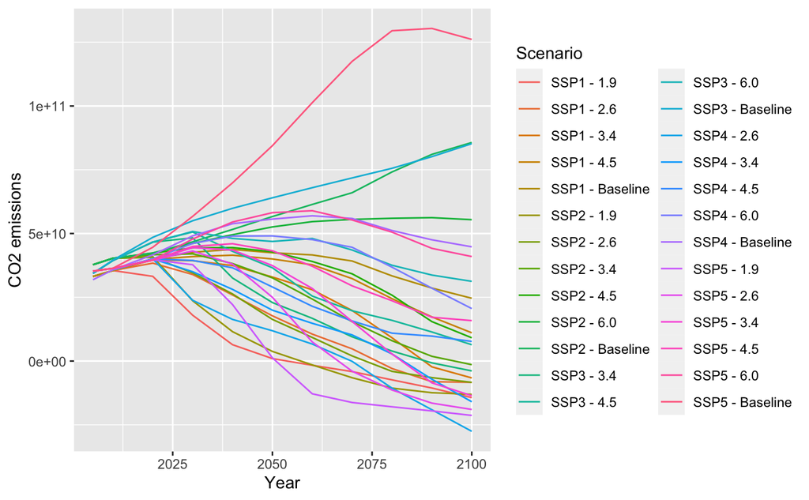

```r
df_owd1 %>% ggplot(aes(x = Year, y = `CO2 emissions`, color = Scenario)) +
  geom_line()
```